# Scrublet: jmjpvq6z_fr6c4nyp

Paula Soler-Vila

2020/04/10

# 1 Introduction

In this notebook, we summarize the doublet detection results obtained after running [Scrublet](https://www.sciencedirect.com/science/article/pii/S2405471218304745). In particular, we run Scrublet for each accessible matrix derived from individual 10X Chip Channels, as recommended in their [notes on best practices](https://github.com/swolock/scrublet).

# 2 Histograms

We start plotting the doublet score histograms for observed epigenome and simulated doublets. We should observe a bimodal distribution in the simulated doublets allowing us to set an accurate threshold. Although Scrublet was designed to detect doublets in scRNA-seq, [SnapATAC](https://www.biorxiv.org/content/10.1101/615179v3.full) authors have suggested that this tool can also be used to find doublets in scATAC-seq datasets as well.

Fang, Rongxin, et al. [SnapATAC](https://www.biorxiv.org/content/10.1101/615179v3.full): a comprehensive analysis package for single cell ATAC-seq." bioRxiv (2020)

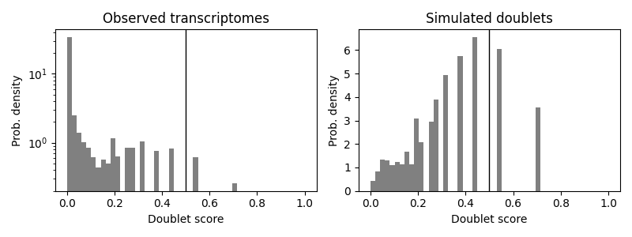

Figure 1: Histogram with the automatic threshold determined by Scrublet

```r
path_to_hist <- paste0("tmp/histograms/scrublet_doublet_prediction_histograms-",gem_id, ".png")
```

# 3 UMAPs

As described in the [Scrublet best practices](https://github.com/swolock/scrublet): - Visualize the doublet predictions in a 2-D embedding (e.g., UMAP or t-SNE). Predicted doublets should mostly co-localize (possibly in multiple clusters). If they do not, you may need to adjust the doublet score threshold, or change the pre-processing parameters to better resolve the cell states present in your data.

```r
path_to_umap <- paste0("tmp/umaps/scrublet_doublet_prediction_umaps-",gem_id, ".png")
```

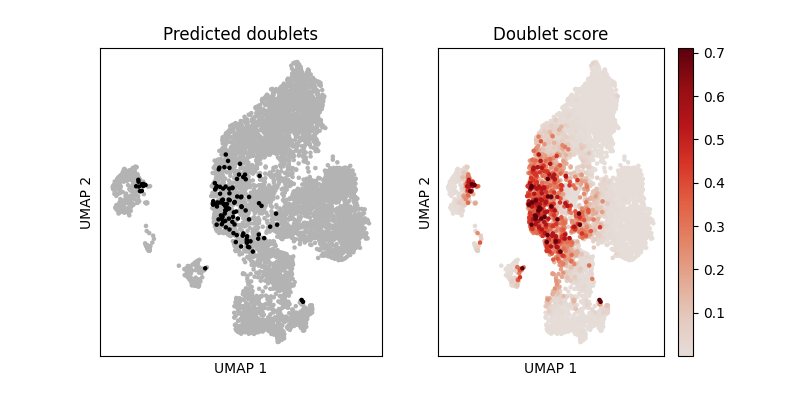

Figure 2: Umap with the automatic threshold determined by Scrublet